## Размерная структура

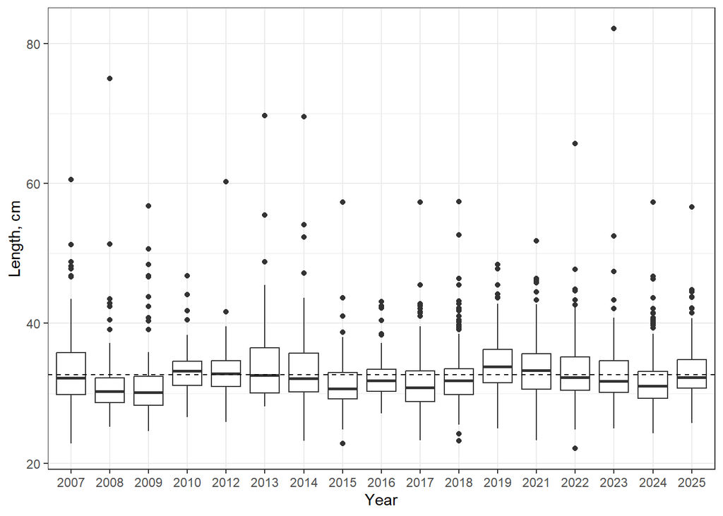

## Динамика полового состава

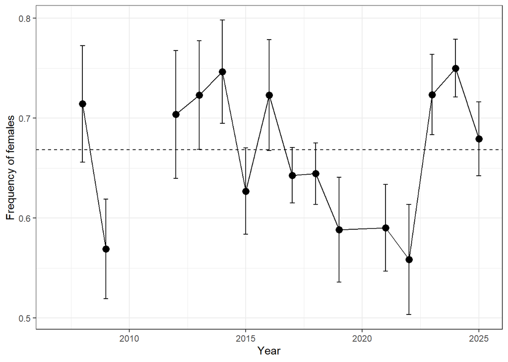

# Общее описание рациона

## Динамика пустых желудков

At! убрал 2016 год!

Модель, котрую строим имеет следующий вид

Empty ~ s(Year) + s(DOY) + s(L), data = total_weight, family = “binomial”

Вот результаты подбора модели

```
##
## Family: binomial
## Link function: logit
##
## Formula:
## Empty ~ s(Year) + s(DOY) + s(L)
##
## Parametric coefficients:
##             Estimate Std. Error z value Pr(>|z|)
## (Intercept) -1.11507    0.05224  -21.34   <2e-16 ***
## ---
## Signif. codes:  0 '***' 0.001 '**' 0.01 '*' 0.05 '.' 0.1 ' ' 1
##
## Approximate significance of smooth terms:
##           edf Ref.df Chi.sq  p-value
## s(Year) 7.297  8.243 33.553 6.51e-05 ***
## s(DOY)  6.864  7.906 68.389  < 2e-16 ***
## s(L)    3.338  4.205  5.382    0.286
## ---
## Signif. codes:  0 '***' 0.001 '**' 0.01 '*' 0.05 '.' 0.1 ' ' 1
##
## R-sq.(adj) =  0.0465   Deviance explained = 4.79%
## UBRE = 0.1042  Scale est. = 1         n = 2107
```

Статистически значимыми была как многолетняя динамика, так и сезонные изменения, но связи с размерами не выявлется.

Вот визуализация модели

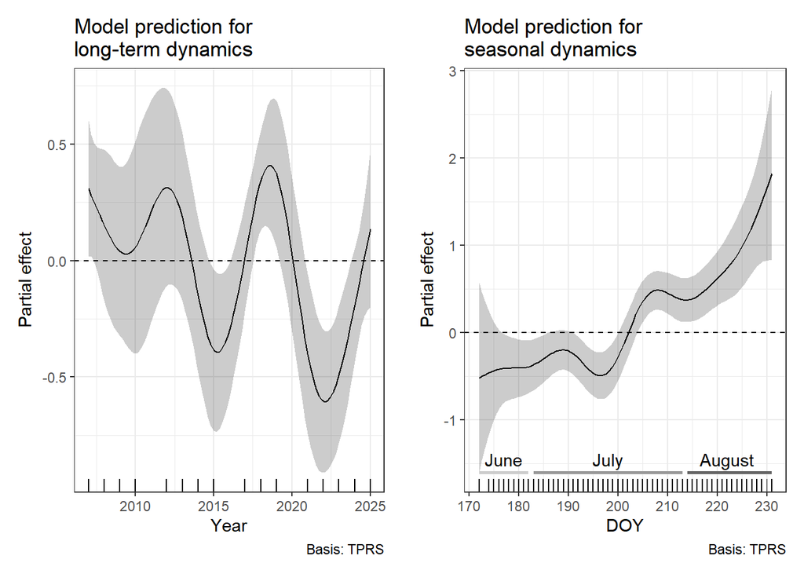

На этих рисунках, как и везде, горизонтальная пунктирная линия отражает среднее по популяции значение. Ниже нуля - меньше среднего и наоборот.

Засечки пока не сделал. Прсто поставить палочки - мне не нравится, пестрит, а более сложную картинку еще не написал.

## Динамика веса пищевого комка в заполненных желудках

Анализируем общий вес пищи в желудках

Модель, котрую строим имеет следующий вид

Total_Weight ~ s(Year) + s(DOY) + s(L)

Вот результаты подбора модели

```
##
## Family: gaussian
## Link function: identity
##
## Formula:
## Total_Weight ~ s(Year) + s(DOY) + s(L, k = 5)
##
## Parametric coefficients:
##             Estimate Std. Error t value Pr(>|t|)
## (Intercept)   8.6887     0.2271   38.26   <2e-16 ***
## ---
## Signif. codes:  0 '***' 0.001 '**' 0.01 '*' 0.05 '.' 0.1 ' ' 1
##
## Approximate significance of smooth terms:
##           edf Ref.df      F p-value
## s(Year) 6.839  7.877  4.588 1.5e-05 ***
## s(DOY)  1.867  2.366  1.237   0.333
## s(L)    3.662  3.934 37.909 < 2e-16 ***
## ---
## Signif. codes:  0 '***' 0.001 '**' 0.01 '*' 0.05 '.' 0.1 ' ' 1
##
## R-sq.(adj) =  0.106   Deviance explained = 11.3%
## GCV = 81.365  Scale est. = 80.669    n = 1564
```

At! Данные за 2016 убрал.

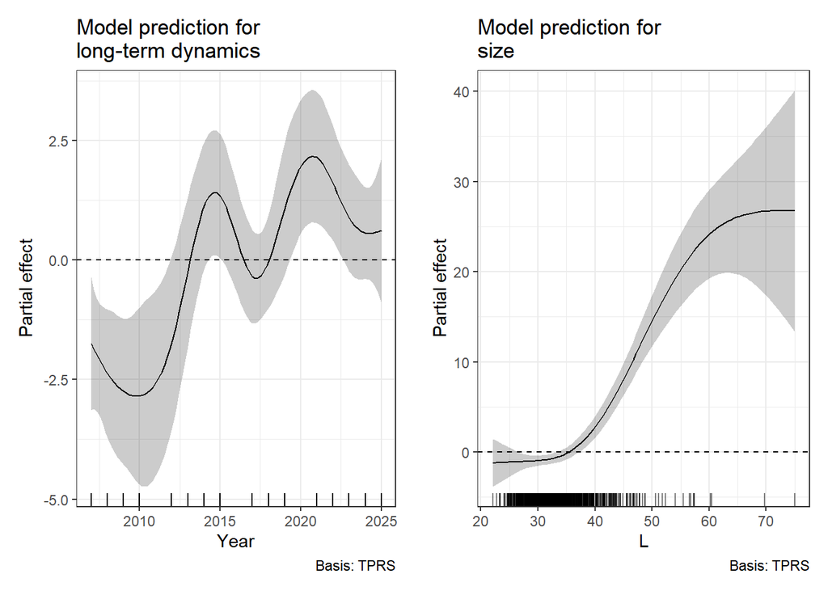

## Состав пищевого комка

## Динамика встречаемости пищевых объектов

Ранжируем виды по их встречаемости (за все годы исследования)

За порог отсечения принимаем встречаемость более 5%. Тогда в число наиболее частых пищевых объектов попадают следующие виды корма:

```
## [1] "G.aculeatus"          "Nereis_sp."           "Fish_eggs"
## [4] "C.pallasii_marisalbi" "O.aculeata"
```

Для этих видов будем строить модель многолетней и сезонной динамики встречаемости.

Модель имеет следующий вид

Presence ~ s(Year, by = Species) + s(DOY, by = Species) + s(L, by = Species, k =5) + Species

То есть мы сразу очениваем и многолетнюю динамику, и сезонную динамику и связь с размерами.

Вот результаты этой модели

```
##
## Family: binomial
## Link function: logit
##
## Formula:
## Presence ~ s(Year, by = Species, k = 5) + s(DOY, by = Species,
##     k = 5) + s(L, by = Species, k = 5) + Species
##
## Parametric coefficients:
##                             Estimate Std. Error z value Pr(>|z|)
## (Intercept)                 -0.21383    0.05600  -3.818 0.000134 ***
## SpeciesC.pallasii_marisalbi -2.69269    0.13831 -19.468  < 2e-16 ***
## SpeciesFish_eggs            -1.82159    0.11468 -15.884  < 2e-16 ***
## SpeciesO.aculeata           -2.51445    0.12297 -20.447  < 2e-16 ***
## SpeciesNereis_sp.           -1.39877    0.09545 -14.655  < 2e-16 ***
## ---
## Signif. codes:  0 '***' 0.001 '**' 0.01 '*' 0.05 '.' 0.1 ' ' 1
##
## Approximate significance of smooth terms:
##                                       edf Ref.df Chi.sq  p-value
## s(Year):SpeciesG.aculeatus          1.952  2.354  8.697 0.017556 *
## s(Year):SpeciesC.pallasii_marisalbi 3.956  3.999 41.817  < 2e-16 ***
## s(Year):SpeciesFish_eggs            1.000  1.001  4.285 0.038529 *
## s(Year):SpeciesO.aculeata           1.000  1.001  0.439 0.507895
## s(Year):SpeciesNereis_sp.           3.946  3.998 78.940  < 2e-16 ***
## s(DOY):SpeciesG.aculeatus           3.148  3.593 99.260  < 2e-16 ***
## s(DOY):SpeciesC.pallasii_marisalbi  2.917  3.442 18.687 0.000539 ***
## s(DOY):SpeciesFish_eggs             3.226  3.649 71.238  < 2e-16 ***
## s(DOY):SpeciesO.aculeata            3.376  3.788 14.608 0.003601 **
## s(DOY):SpeciesNereis_sp.            3.951  3.998 82.526  < 2e-16 ***
## s(L):SpeciesG.aculeatus             3.348  3.774 68.306  < 2e-16 ***
## s(L):SpeciesC.pallasii_marisalbi    1.000  1.001  7.846 0.005103 **
## s(L):SpeciesFish_eggs               3.421  3.820 56.745  < 2e-16 ***
## s(L):SpeciesO.aculeata              1.001  1.001  4.029 0.044772 *
## s(L):SpeciesNereis_sp.              1.000  1.001 10.223 0.001390 **
## ---
## Signif. codes:  0 '***' 0.001 '**' 0.01 '*' 0.05 '.' 0.1 ' ' 1
##
## R-sq.(adj) =  0.222   Deviance explained = 21.9%
## UBRE = -0.22123  Scale est. = 1         n = 7820
```

Не выявлена многолетняя динамика только у O.aculeata (!!! Отличается от предыдущего результата, когда 2016 использовал).

Связь с размерами есть у всех (!!! Отличается от предыдущего результата).

**Встречаемость видов в зависимости от размеров трески**

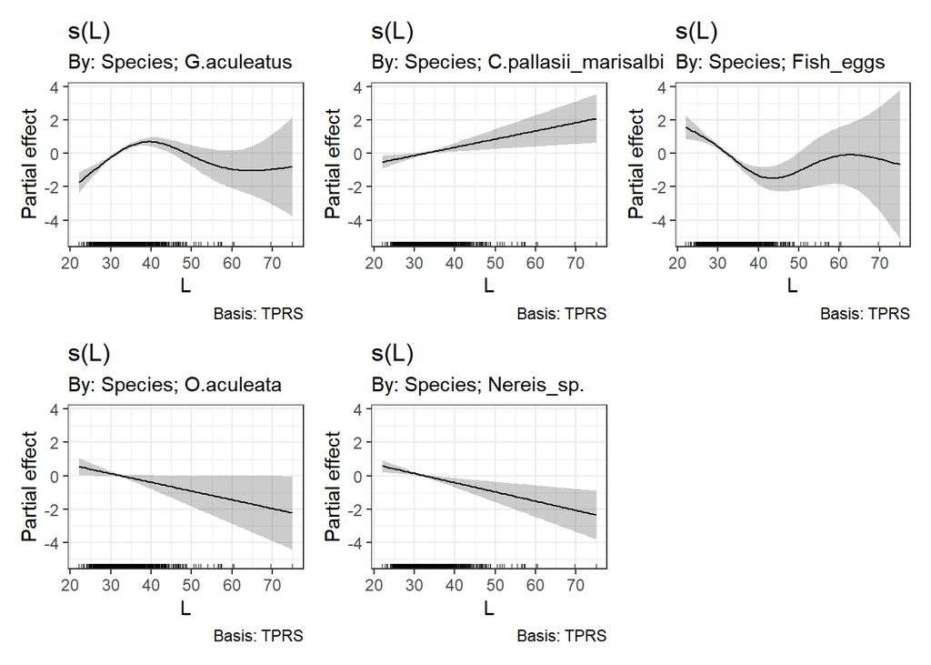

**Сезонная динамика встречаемости видов**

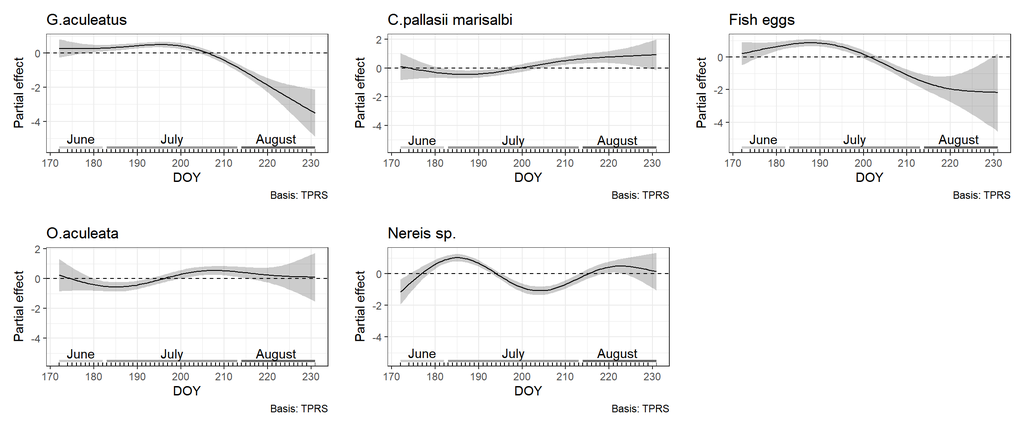

Первую половину лета треска ест колюшку и икру, вторую половину лета - селедку и, возможно, офиур. С нереисами сложнее. Первый пик - это явно период хода нереиса в первой половине лета. Второй пик - может это другой вид нереиса? Надо поискать данные по периодам хода у pelgica и virens.

**Многолетняя динамика встречаемости видов**

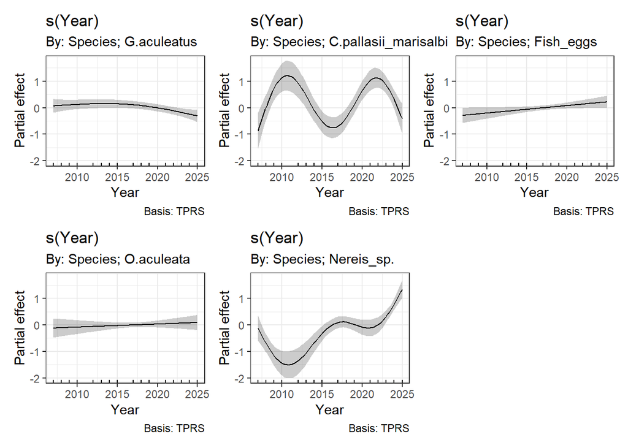

## Динамика доли пищевых объектов

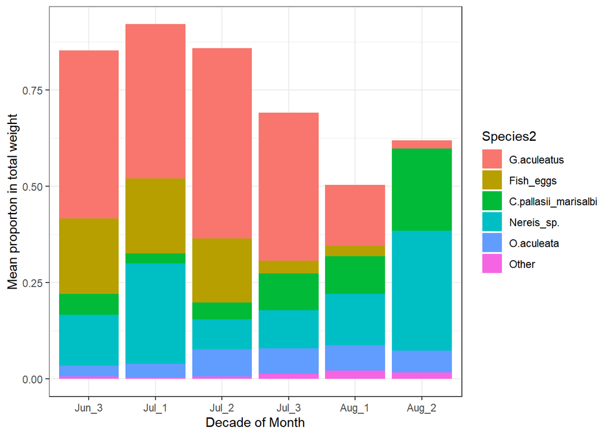

# Новый кусок

## Другой способ вычисления доли

За 100% берется вся сумма весов жертв за декаду. Далее на графике отражаем долю суммы каждого вида в общей сумме за декаду.

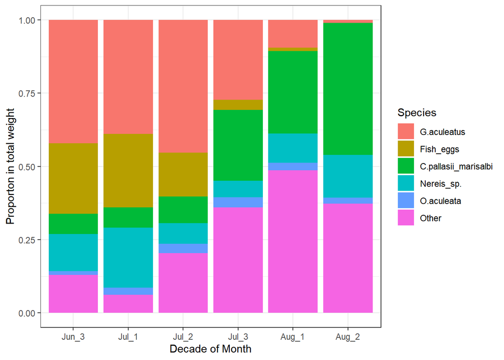

Это другой способ визуализации предыдущего графика. Этот вариант мне кажется лучше. В принципе, можно пустить его в параллель с визуализацией сезонной динамики встречаемости видов (общий ход сезонной динамики встречаемости и доли в пищевом комке похожи)

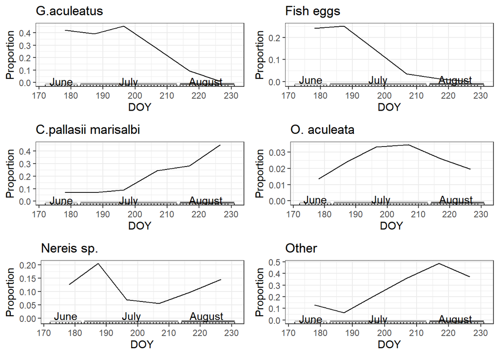

## Многолетняя динамика доли

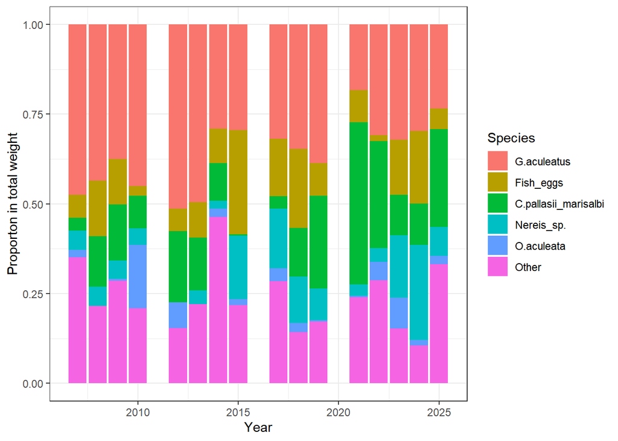

Другой вариант визуализации этого же графика. Здесь точки - исходные доли, синие линии - сглаженная тенденция.

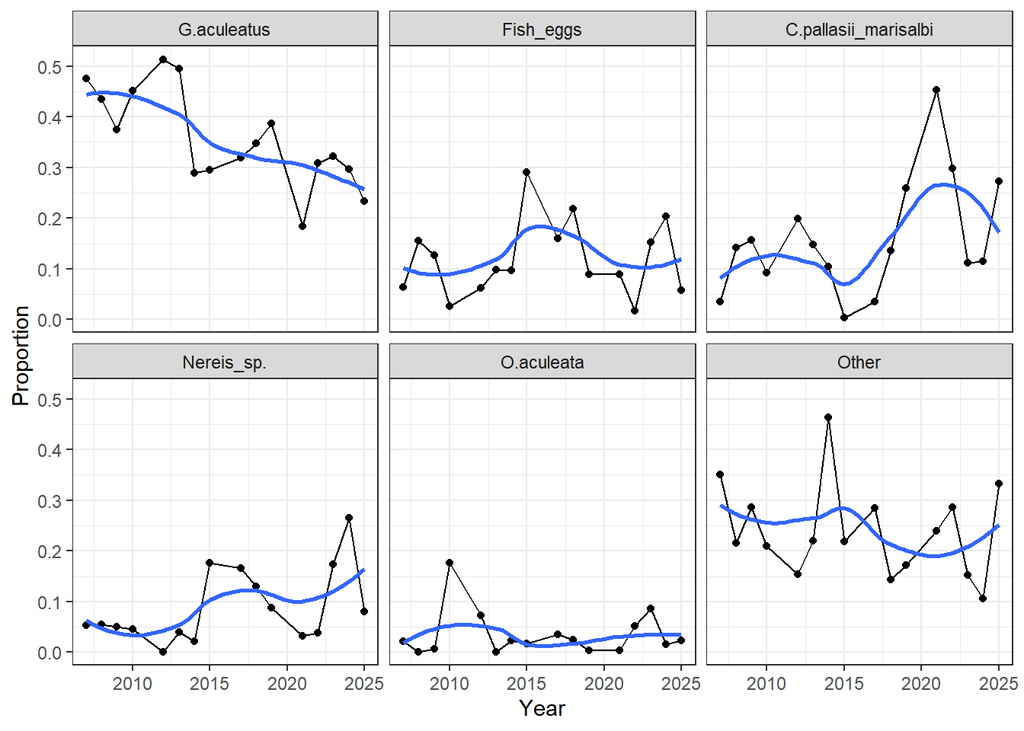